# **Comcast Telecom Consumer Complaints**

### Importing Libraries

```python
import pandas as pd
import numpy as np
import matplotlib.pyplot as plt
import matplotlib
```

### Importing Comcast Data File

```python
Com_df = pd.read_csv("Comcast_telecom_complaints_data.csv")
```

Imported the data to Google Colab.

### Inspecting the data

```python
Com_df.head()
```

|  | Ticket # | Customer Complaint | Date | Date_month_year | Time | Received Via | City | State | Zip code | Status | Filing on Behalf of Someone |
| --- | --- | --- | --- | --- | --- | --- | --- | --- | --- | --- | --- |
| 0 | 250635 | Comcast Cable Internet Speeds | 22-04-15 | 22-Apr-15 | 3:53:50 PM | Customer Care Call | Abingdon | Maryland | 21009 | Closed | No |
| 1 | 223441 | Payment disappear - service got disconnected | 04-08-15 | 04-Aug-15 | 10:22:56 AM | Internet | Acworth | Georgia | 30102 | Closed | No |
| 2 | 242732 | Speed and Service | 18-04-15 | 18-Apr-15 | 9:55:47 AM | Internet | Acworth | Georgia | 30101 | Closed | Yes |
| 3 | 277946 | Comcast Imposed a New Usage Cap of 300GB that ... | 05-07-15 | 05-Jul-15 | 11:59:35 AM | Internet | Acworth | Georgia | 30101 | Open | Yes |
| 4 | 307175 | Comcast not working and no service to boot | 26-05-15 | 26-May-15 | 1:25:26 PM | Internet | Acworth | Georgia | 30101 | Solved | No |

```python
Com_df.info()
```

```
<class 'pandas.core.frame.DataFrame'>
RangeIndex: 2224 entries, 0 to 2223
Data columns (total 11 columns):
 #   Column                       Non-Null Count  Dtype
---  ------                       --------------  -----
 0   Ticket #                     2224 non-null   object
 1   Customer Complaint           2224 non-null   object
 2   Date                         2224 non-null   object
 3   Date_month_year              2224 non-null   object
 4   Time                         2224 non-null   object
 5   Received Via                 2224 non-null   object
 6   City                         2224 non-null   object
 7   State                        2224 non-null   object
 8   Zip code                     2224 non-null   int64
 9   Status                       2224 non-null   object
 10  Filing on Behalf of Someone  2224 non-null   object
dtypes: int64(1), object(10)
memory usage: 191.2+ KB
```

No Null values found. However, values in column Date appears as object. Need to convert to 'datetime' for further analysis.

```python
Com_df["Date"] = pd.to_datetime(Com_df["Date"])
```

```python
Com_df.info()
```

```
<class 'pandas.core.frame.DataFrame'>
RangeIndex: 2224 entries, 0 to 2223
Data columns (total 11 columns):
 #   Column                       Non-Null Count  Dtype
---  ------                       --------------  -----
 0   Ticket #                     2224 non-null   object
 1   Customer Complaint           2224 non-null   object
 2   Date                         2224 non-null   datetime64[ns]
 3   Date_month_year              2224 non-null   object
 4   Time                         2224 non-null   object
 5   Received Via                 2224 non-null   object
 6   City                         2224 non-null   object
 7   State                        2224 non-null   object
 8   Zip code                     2224 non-null   int64
 9   Status                       2224 non-null   object
 10  Filing on Behalf of Someone  2224 non-null   object
dtypes: datetime64[ns](1), int64(1), object(9)
memory usage: 191.2+ KB
```

Date column got converted to date type - datetime

### Month Level Chart of Complaints

```python
Com_df["Month"] = pd.DatetimeIndex(Com_df["Date"]).month
```

```python
Com_dfGrMonth = Com_df.groupby(Com_df["Month"])
```

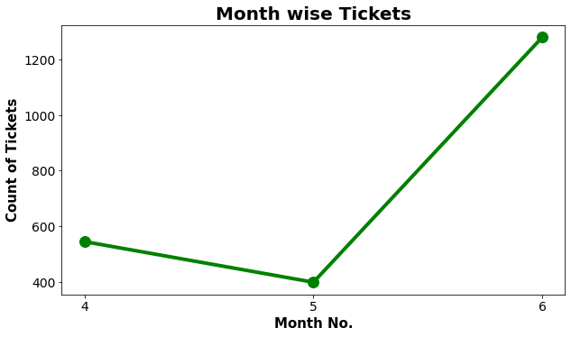

```python
plt.figure(figsize=(10,5.5))
MoM_Tickets = plt.plot(Com_dfGrMonth["Ticket #"].count(), color = 'green',linewidth=4, marker = 'o',ms=12)
plt.xticks(np.arange(Com_df['Month'].min(), Com_df['Month'].max()+1, 1.0),fontsize=14)
plt.yticks(fontsize=14)
plt.title("Month wise Tickets",fontsize=20,weight = 'bold')
plt.xlabel("Month No.",fontsize=15,weight = 'semibold')
plt.ylabel("Count of Tickets",fontsize=15,weight = 'semibold')
plt.show()
```

Extracted month number from the dates and created month level ticket count line chart. The negative slope from 4th to 5th month in the chart indicates a reduction of complaints in the 5th month. Similarly, the steep positive slope of the line after 5th month indicates that the complaints were very high in the 6th month

### Date Level Chart of Complaints

```python
Com_dfGrDate = Com_df.groupby(Com_df["Date"])
```

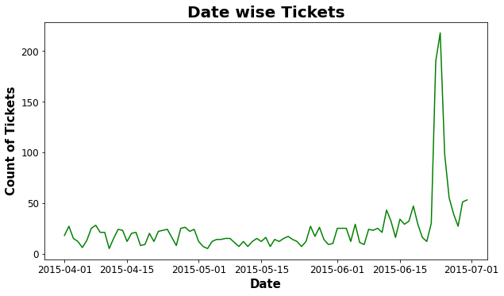

```python
plt.figure(figsize=(10,5.5))
Daywise_Tickets = plt.plot(Com_dfGrDate["Ticket #"].count(), color = 'green',linewidth=1.5)
plt.xticks(fontsize=12)
plt.yticks(fontsize=12)
plt.title("Date wise Tickets",fontsize=20,weight = 'bold')
plt.xlabel("Date",fontsize=15,weight = 'semibold')
plt.ylabel("Count of Tickets",fontsize=15,weight = 'semibold')
plt.show()
```

On reviewing the date level chart, we see a bump around the last week of 6th month. This is indicative of sudden increase in the complaints during the period.

### Table with frequency of Complaint Types

```python
Comp_Types = Com_df["Customer Complaint"].value_counts().reset_index()
Comp_Types.columns = ['Complaint Types','Count']
Comp_Types
```

|  | Complaint Types | Count |
| --- | --- | --- |
| 0 | Comcast | 83 |
| 1 | Comcast Internet | 18 |
| 2 | Comcast Data Cap | 17 |
| 3 | comcast | 13 |
| 4 | Comcast Data Caps | 11 |
| ... | ... | ... |
| 1836 | local monopoly | 1 |
| 1837 | Un able to access my email address after reloc... | 1 |
| 1838 | Comcast charging me monthly fees for equipment... | 1 |
| 1839 | Xfinity/comcast Service | 1 |
| 1840 | Comcast charging ridiculous prices | 1 |

1841 rows × 2 columns

### Max Complaint Types

```python
Top_3_Complaint_Types = Comp_Types[0:3]
Top_3_Complaint_Types
```

|  | Complaint Types | Count |
| --- | --- | --- |
| 0 | Comcast | 83 |
| 1 | Comcast Internet | 18 |
| 2 | Comcast Data Cap | 17 |

Top three categories of the complaints are ‘Comcast’, ‘Internet issues’ and ‘Cap on data’

### Creating a new Categorical Variable for Status Types

```python
Status_Types = Com_df["Status"].value_counts()
print(Status_Types)
```

```
Solved     973
Closed     734
Open       363
Pending    154
Name: Status, dtype: int64
```

Originally, we have 4 status types in Status Column

```python
Com_df['New Status'] = Com_df["Status"].replace({"Pending":"Open","Solved":"Closed"})
Com_df['New Status']
```

```
0       Closed
1       Closed
2       Closed
3         Open
4       Closed
         ...
2219    Closed
2220    Closed
2221    Closed
2222    Closed
2223      Open
Name: New Status, Length: 2224, dtype: object
```

```python
Com_df['New Status'].value_counts()
```

```
Closed    1707
Open       517
Name: New Status, dtype: int64
```

After categorising and based on our analysis we see that out of total complaints received; 1707 have been Closed (closed + resolved) & 517 are open.

### State wise Status of Complaints in a Stacked bar Chart

```python
State_Status = pd.crosstab(Com_df["State"],Com_df['New Status']).reset_index()
State_Status.sort_values(by=["Closed"], ascending=False,inplace=True)
```

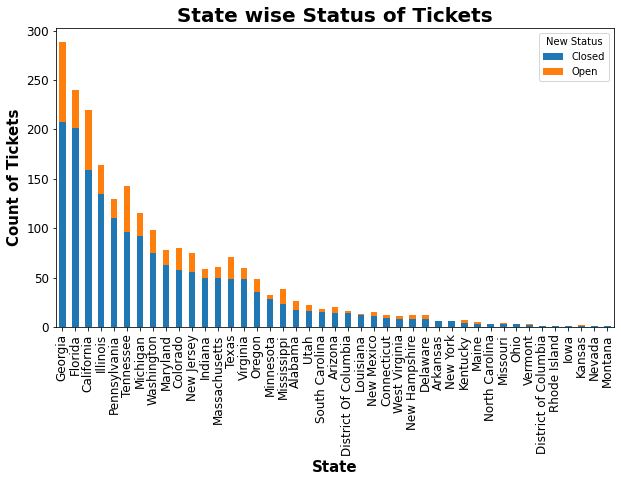

```python
plt.rcParams['figure.figsize']= (10,5.5)
State_Status.plot(x="State", y=["Closed", "Open"], kind="bar",stacked=True)
plt.xticks(fontsize=12)
plt.yticks(fontsize=12)
plt.title("State wise Status of Tickets",fontsize=20,weight = 'bold')
plt.xlabel("State",fontsize=15,weight = 'semibold')
plt.ylabel("Count of Tickets",fontsize=15,weight = 'semibold')
plt.show()
```

### Identifying State with maximum complaints

```python
State_wise_Counts = Com_df['State'].value_counts()
State_wise_Counts[0:1]
```

```
Georgia    288
Name: State, dtype: int64
```

Georgia has the maximum number of complaints – 288

### Identifying the State with maximum complaints (chart)

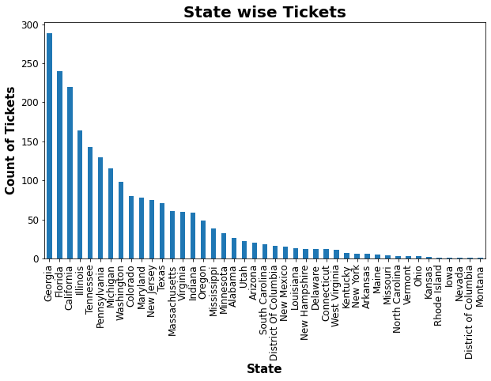

```python
plt.figure(figsize=(10,5.5))
Com_df['State'].value_counts().plot(kind='bar');
plt.xticks(fontsize=12)
plt.yticks(fontsize=12)
plt.title("State wise Tickets",fontsize=20,weight = 'bold')
plt.xlabel("State",fontsize=15,weight = 'semibold')
plt.ylabel("Count of Tickets",fontsize=15,weight = 'semibold')
plt.show()
```

Looking at the chart we can say that Georgia has the maximum number of Complaints received

### State with highest Unresolved Complaints

```python
State_Max_Open_Comp = Com_df.groupby(['State','New Status']).size().sort_values(ascending = False).reset_index(name = 'Count').drop_duplicates(subset = 'New Status')
print(State_Max_Open_Comp)
```

```
     State New Status  Count
0  Georgia     Closed    208
7  Georgia       Open     80
```

### Channel wise Complaint Status

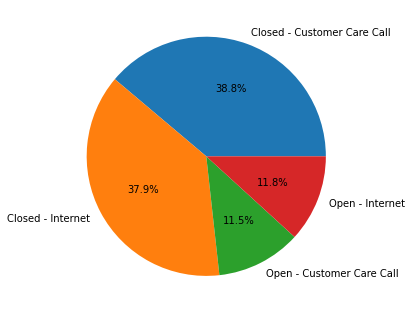

```python
Channel_Status = Com_df[["Received Via","New Status","Ticket #"]]
Channel_Status_df = Channel_Status.pivot_table(index=["New Status","Received Via"],values="Ticket #",aggfunc='count').reset_index()
plt.pie(Channel_Status_df["Ticket #"],labels=["Closed - Customer Care Call","Closed - Internet","Open - Customer Care Call","Open - Internet"],autopct="%0.1f%%");
```

% of complaints resolved till date = 76.7% | Received through Cust. Care Calls = 38.8% | Received through internet = 37.9%